# Matthew Bierman, Homework 2

# Problem 1: Simple Linear Regression

## 1.

```r
library(ISLR)
data(Auto)
names(Auto)
```

```
## [1] "mpg"          "cylinders"    "displacement" "horsepower"
## [5] "weight"       "acceleration" "year"         "origin"
## [9] "name"
```

```r
summary(Auto)
```

```
##       mpg          cylinders      displacement     horsepower
##  Min.   : 9.00   Min.   :3.000   Min.   : 68.0   Min.   : 46.0
##  1st Qu.:17.00   1st Qu.:4.000   1st Qu.:105.0   1st Qu.: 75.0
##  Median :22.75   Median :4.000   Median :151.0   Median : 93.5
##  Mean   :23.45   Mean   :5.472   Mean   :194.4   Mean   :104.5
##  3rd Qu.:29.00   3rd Qu.:8.000   3rd Qu.:275.8   3rd Qu.:126.0
##  Max.   :46.60   Max.   :8.000   Max.   :455.0   Max.   :230.0
##
##      weight      acceleration        year           origin
##  Min.   :1613   Min.   : 8.00   Min.   :70.00   Min.   :1.000
##  1st Qu.:2225   1st Qu.:13.78   1st Qu.:73.00   1st Qu.:1.000
##  Median :2804   Median :15.50   Median :76.00   Median :1.000
##  Mean   :2978   Mean   :15.54   Mean   :75.98   Mean   :1.577
##  3rd Qu.:3615   3rd Qu.:17.02   3rd Qu.:79.00   3rd Qu.:2.000
##  Max.   :5140   Max.   :24.80   Max.   :82.00   Max.   :3.000
##
##                  name
##  amc matador       :  5
##  ford pinto        :  5
##  toyota corolla    :  5
##  amc gremlin       :  4
##  amc hornet        :  4
##  chevrolet chevette:  4
##  (Other)           :365
```

```r
set.seed(1234)
i <- sample(1:nrow(Auto), nrow(Auto) * 0.75, replace = FALSE)
train <- Auto[i,]
test <- Auto[-i,]
```

## 2.

```r
lm1 <- lm(mpg~horsepower, data = train)
summary(lm1)
```

```
##
## Call:
## lm(formula = mpg ~ horsepower, data = train)
##
## Residuals:
##      Min       1Q   Median       3Q      Max
## -13.2314  -3.4895  -0.3689   2.8210  17.2986
##
## Coefficients:
##              Estimate Std. Error t value Pr(>|t|)
## (Intercept) 39.237421   0.831703   47.18   <2e-16 ***
## horsepower  -0.152862   0.007436  -20.56   <2e-16 ***
## ---
## Signif. codes:  0 '***' 0.001 '**' 0.01 '*' 0.05 '.' 0.1 ' ' 1
##
## Residual standard error: 4.993 on 292 degrees of freedom
## Multiple R-squared:  0.5914, Adjusted R-squared:   0.59
## F-statistic: 422.6 on 1 and 292 DF,  p-value: < 2.2e-16
```

```r
mse0 <- mean(lm1$residuals ^ 2)
mse0
```

```
## [1] 24.76078
```

## 3.

a.) y-hat = 39.237 - 0.153x

b.) Since the R-squared value is 0.59, there is a moderately strong relationship between mpg and horsepower.

c.) It is a negative correlation

e.) MSE: The mean squared error is 24.761, which is not close to 0, meaning horsepower is a good, but not the best, predictor of mpg.

## 4.

The data fits the line moderately well, but the data seems to have a curved/nonlinear feature, so linear regression might not be best.

Prediction of 98 hp: y-hat = 39.237 - 0.153(98) = **24.243**

A value of 24.243 mpg for 98 hp seems to match well with the values of the dataset within the 90-100 hp range.

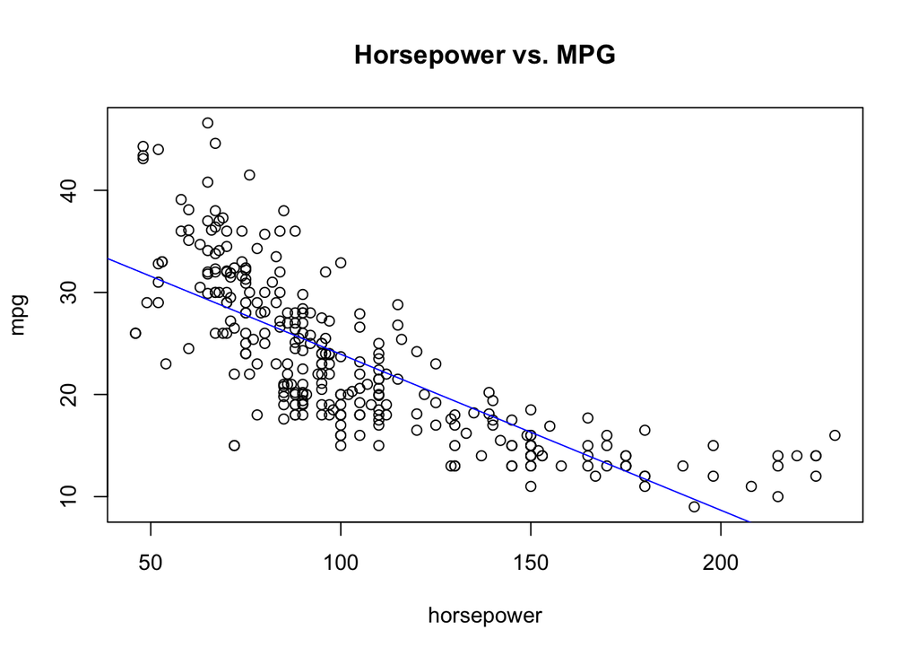

```r
plot(mpg~horsepower, data = train, main = paste("Horsepower vs. MPG"))
abline(lm1, col="blue")
```

## 5.

With a correlation value of 0.812, there is a strong correlation between the predicted values and the actual mpg values.

The MSE is 578.47, which is a lot higher than on the training data, which suggests that it is not a good predictor of mpg.

```r
predicted1 <- predict(lm1, test)
cor(predicted1, test$mpg)
```

```
## [1] 0.8123764
```

```r
mse1 <- mean(predicted1 ^ 2)
mse1
```

```
## [1] 578.4694
```

## 6.

The Residuals vs Fitted graph shows evidence of a nonlinear line of best fit.

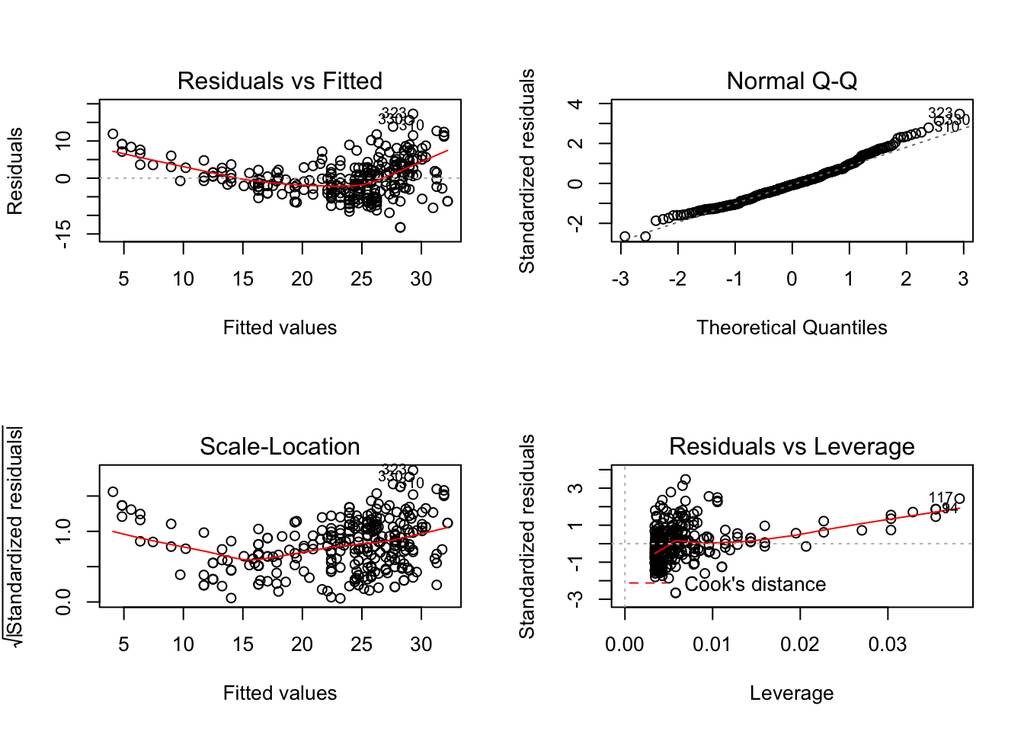

```r
par(mfrow=c(2, 2))
plot(lm1)
```

## 7.

The second linear model has a R-squared value of 0.6757, compared to the R-squared value of 0.59 for the first linear model, showing that using log(mpg) fits the line of best fit a little bit better.

```r
lm2 <- lm(log(mpg)~horsepower, data = train)
summary(lm2)
```

```
##
## Call:
## lm(formula = log(mpg) ~ horsepower, data = train)
##
## Residuals:
##     Min      1Q  Median      3Q     Max
## -0.6135 -0.1284  0.0124  0.1324  0.5735
##
## Coefficients:
##               Estimate Std. Error t value Pr(>|t|)
## (Intercept)  3.8330703  0.0321342  119.28   <2e-16 ***
## horsepower  -0.0071041  0.0002873  -24.73   <2e-16 ***
## ---
## Signif. codes:  0 '***' 0.001 '**' 0.01 '*' 0.05 '.' 0.1 ' ' 1
##
## Residual standard error: 0.1929 on 292 degrees of freedom
## Multiple R-squared:  0.6768, Adjusted R-squared:  0.6757
## F-statistic: 611.5 on 1 and 292 DF,  p-value: < 2.2e-16
```

## 8.

This line fits the data slightly better than with the data without using log.

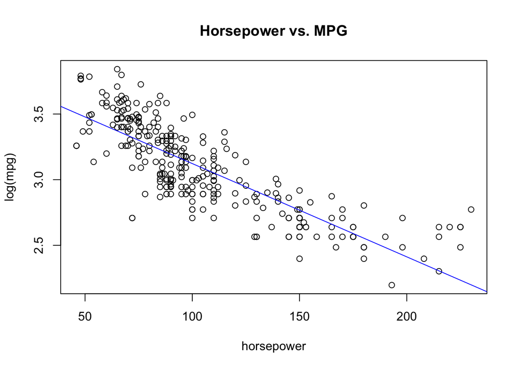

```r
plot(log(mpg)~horsepower, data = train, main = paste("Horsepower vs. MPG"))
abline(lm2, col="blue")
```

## 9.

The correlation of the lm2 predictions is the same as for lm1, but the MSE is much closer to 0 in lm2 than lm1, meaning it fits the data much better.

```r
predicted2 <- predict(lm2, test)
cor(predicted2, test$mpg)
```

```
## [1] 0.8123764
```

```r
mse2 <- mean(predicted2 ^ 2)
mse2
```

```
## [1] 9.659738
```

## 10.

With lm2, the residuals are much lower compared to lm1, as the maximum residual has a magnitude of 0.6, whereas the maximum residual of lm1 has a magnitude of almost 20.

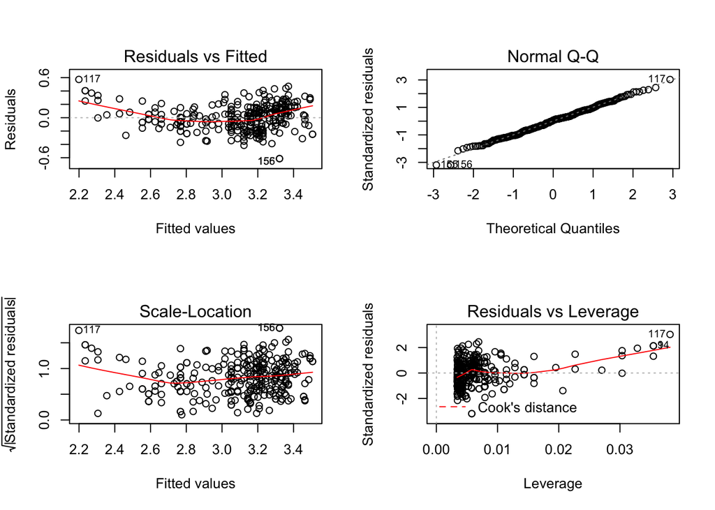

```r
par(mfrow=c(2, 2))
plot(lm2)
```

# Problem 2: Multiple Linear Regression

## 1.

Positive Correlation:

1. Displacement and Weight
2. Horsepower and Weight
3. Displacement and Horsepower

Negative Correlation:

1. MPG and Displacement
2. MPG and Horsepower
3. MPG and Weight

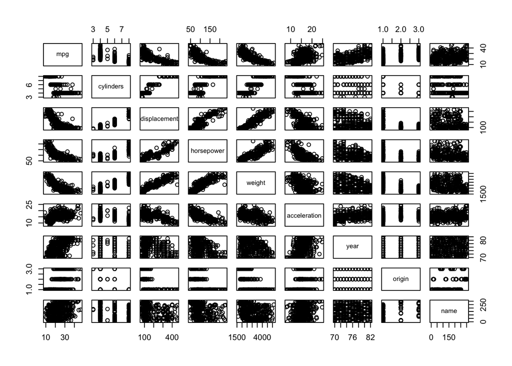

```r
pairs(Auto)
```

## 2.

Two Strongest Positive Correlations:

1. Displacement and Weight
2. Displacement and Horsepower

Two Strongest Negative Correlations:

1. MPG and Weight
2. MPG and Displacement

```r
cor(Auto$displacement, Auto$weight)
```

```
## [1] 0.9329944
```

```r
cor(Auto$horsepower, Auto$weight)
```

```
## [1] 0.8645377
```

```r
cor(Auto$displacement, Auto$horsepower)
```

```
## [1] 0.897257
```

```r
cor(Auto$mpg, Auto$displacement)
```

```
## [1] -0.8051269
```

```r
cor(Auto$mpg, Auto$horsepower)
```

```
## [1] -0.7784268
```

```r
cor(Auto$mpg, Auto$weight)
```

```
## [1] -0.8322442
```

## 3.

```r
Auto$origin <- factor(Auto$origin)
lm3 <- lm(mpg~.-name, data = Auto)
summary(lm3)
```

```
##
## Call:
## lm(formula = mpg ~ . - name, data = Auto)
##
## Residuals:
##     Min      1Q  Median      3Q     Max
## -9.0095 -2.0785 -0.0982  1.9856 13.3608
##
## Coefficients:
##                Estimate Std. Error t value Pr(>|t|)
## (Intercept)  -1.795e+01  4.677e+00  -3.839 0.000145 ***
## cylinders    -4.897e-01  3.212e-01  -1.524 0.128215
## displacement  2.398e-02  7.653e-03   3.133 0.001863 **
## horsepower   -1.818e-02  1.371e-02  -1.326 0.185488
## weight       -6.710e-03  6.551e-04 -10.243  < 2e-16 ***
## acceleration  7.910e-02  9.822e-02   0.805 0.421101
## year          7.770e-01  5.178e-02  15.005  < 2e-16 ***
## origin2       2.630e+00  5.664e-01   4.643 4.72e-06 ***
## origin3       2.853e+00  5.527e-01   5.162 3.93e-07 ***
## ---
## Signif. codes:  0 '***' 0.001 '**' 0.01 '*' 0.05 '.' 0.1 ' ' 1
##
## Residual standard error: 3.307 on 383 degrees of freedom
## Multiple R-squared:  0.8242, Adjusted R-squared:  0.8205
## F-statistic: 224.5 on 8 and 383 DF,  p-value: < 2.2e-16
```

## 4.

There seems to be rather large residuals, with some data points reaching a residual magnitude of 15. Row 14 seems to be a leverage point

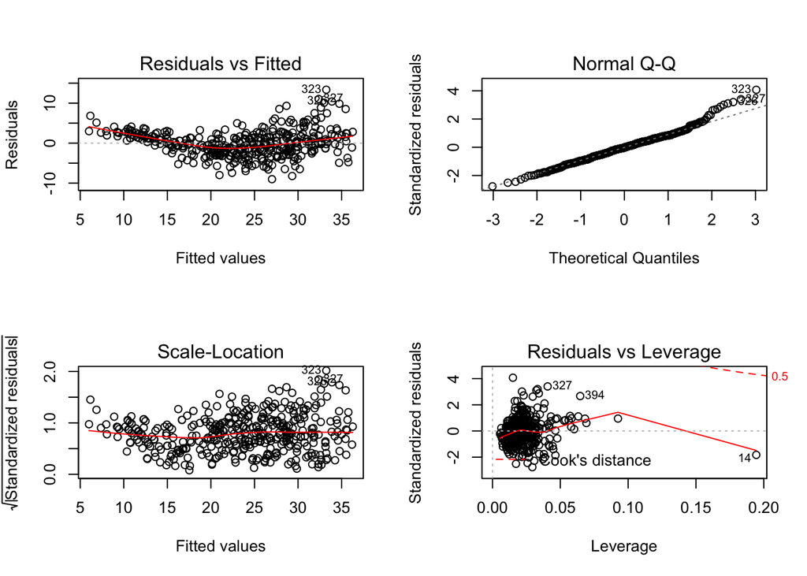

```r
 par(mfrow=c(2,2))
 plot(lm3)
```

```r
 Auto[14,]
```

```
##    mpg cylinders displacement horsepower weight acceleration year origin
## 14  14         8          455        225   3086           10   70      1
##                       name
## 14 buick estate wagon (sw)
```

## 5.

Using mpg ~ weight + displacement + year resulted in an R-squared value of 0.8067 with the same p-value, but mpg ~ weight * displacement * year resulted in an R-squared value of 0.8571 and a smaller F-statistic.

```r
lm4 <- lm(mpg~weight+displacement+year, data = Auto)
summary(lm4)
```

```
##
## Call:
## lm(formula = mpg ~ weight + displacement + year, data = Auto)
##
## Residuals:
##     Min      1Q  Median      3Q     Max
## -8.8400 -2.2917 -0.1177  2.0420 14.3559
##
## Coefficients:
##                Estimate Std. Error t value Pr(>|t|)
## (Intercept)  -1.436e+01  4.021e+00  -3.572 0.000398 ***
## weight       -6.664e-03  5.710e-04 -11.670  < 2e-16 ***
## displacement  2.835e-04  4.744e-03   0.060 0.952382
## year          7.580e-01  5.100e-02  14.863  < 2e-16 ***
## ---
## Signif. codes:  0 '***' 0.001 '**' 0.01 '*' 0.05 '.' 0.1 ' ' 1
##
## Residual standard error: 3.432 on 388 degrees of freedom
## Multiple R-squared:  0.8082, Adjusted R-squared:  0.8067
## F-statistic: 544.9 on 3 and 388 DF,  p-value: < 2.2e-16
```

```r
lm5 <- lm(mpg~weight*displacement*year, data = Auto)
summary(lm5)
```

```
##
## Call:
## lm(formula = mpg ~ weight * displacement * year, data = Auto)
##
## Residuals:
##     Min      1Q  Median      3Q     Max
## -9.6093 -1.6472 -0.0531  1.2289 14.5604
##
## Coefficients:
##                            Estimate Std. Error t value Pr(>|t|)
## (Intercept)              -8.437e+01  3.128e+01  -2.697   0.0073 **
## weight                    8.489e-03  1.322e-02   0.642   0.5212
## displacement              3.434e-01  1.969e-01   1.744   0.0820 .
## year                      1.828e+00  4.127e-01   4.430 1.23e-05 ***
## weight:displacement      -6.589e-05  5.055e-05  -1.303   0.1932
## weight:year              -2.433e-04  1.744e-04  -1.395   0.1638
## displacement:year        -5.566e-03  2.674e-03  -2.082   0.0380 *
## weight:displacement:year  1.144e-06  6.823e-07   1.677   0.0944 .
## ---
## Signif. codes:  0 '***' 0.001 '**' 0.01 '*' 0.05 '.' 0.1 ' ' 1
##
## Residual standard error: 2.951 on 384 degrees of freedom
## Multiple R-squared:  0.8596, Adjusted R-squared:  0.8571
## F-statistic:   336 on 7 and 384 DF,  p-value: < 2.2e-16
```

```r
anova(lm4, lm5)
```

```
## Analysis of Variance Table
##
## Model 1: mpg ~ weight + displacement + year
## Model 2: mpg ~ weight * displacement * year
##   Res.Df    RSS Df Sum of Sq      F    Pr(>F)
## 1    388 4568.9
## 2    384 3343.4  4    1225.5 35.188 < 2.2e-16 ***
## ---
## Signif. codes:  0 '***' 0.001 '**' 0.01 '*' 0.05 '.' 0.1 ' ' 1
```